# Mini-Project 01: Netflix Press Room

**CODE: CSS**

```css
table.dataTable thead th {
  font-size: 12px !important;
}
table.dataTable tbody td {
  font-size: 12px !important;
}

.img-left {
  float: left;
  margin-right: 15px;
  margin-bottom: 10px;
  max-width: 300px;
}

.img-right {
  float: right;
  margin-left: 15px;
  margin-bottom: 10px;
  max-width: 300px;
}

.clear {
  clear: both;
}
```

[figure not shown]

## Dressing for my new job

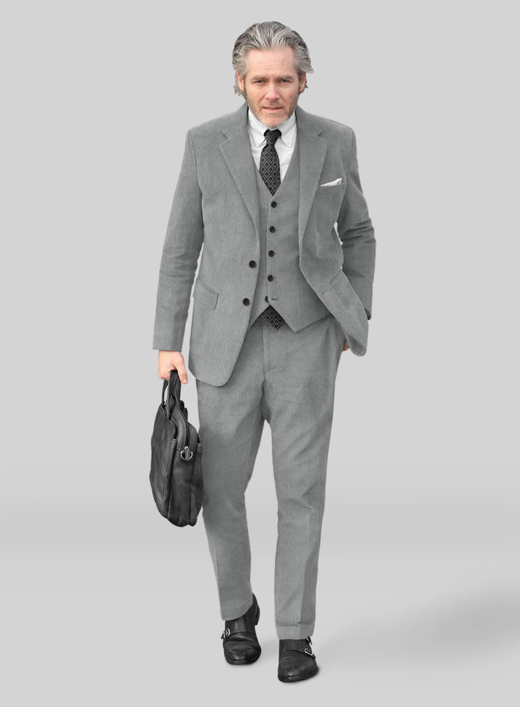

As a newly hired **data analyst** with the **Netflix** PR team, I think I’m going to need to buy some new clothes. It’s October and there is a chill in the air. I’m thinking corduroy.

Maybe something like this?

## Getting Started

For my first report, I’ll be using [Netflix’s TuDum Top Ten](https://www.netflix.com/tudum/top10) data to uncover recent trends. This data is divided into two sets:

- Global Top 10
- Country-wide Top 10

Let’s get started by downloading the data.

**CODE: Download and setup data files**

```r
if(!dir.exists(file.path("data", "mp01"))){
    dir.create(file.path("data", "mp01"), showWarnings=FALSE, recursive=TRUE)
}

GLOBAL_TOP_10_FILENAME <- file.path("data", "mp01", "global_top10_alltime.csv")

if(!file.exists(GLOBAL_TOP_10_FILENAME)){
    download.file("https://www.netflix.com/tudum/top10/data/all-weeks-global.tsv",
                  destfile=GLOBAL_TOP_10_FILENAME)
}

COUNTRY_TOP_10_FILENAME <- file.path("data", "mp01", "country_top10_alltime.csv")

if(!file.exists(COUNTRY_TOP_10_FILENAME)){
    download.file("https://www.netflix.com/tudum/top10/data/all-weeks-countries.tsv",
                  destfile=COUNTRY_TOP_10_FILENAME)
}
```

Now that we have data, let’s load some r libraries that we will be using, create some variables to hold dataframes, and begin to clean the data.

**CODE: Create dataframe objects and remove nulls**

```r
if(!require("tidyverse")) install.packages("tidyverse")
library(readr)
library(dplyr)

GLOBAL_TOP_10 <- read_tsv(GLOBAL_TOP_10_FILENAME)

GLOBAL_TOP_10 <- GLOBAL_TOP_10 |>
  mutate(season_title = if_else(season_title=="N/A", NA, season_title))

COUNTRY_TOP_10 <- read_tsv(COUNTRY_TOP_10_FILENAME, na = c("N/A"))
```

## Initial Data Exploration

Let’s take a peek at a few rows of the Global Top 10 data. We’ll spruce up the table a bit with a few touch-ups:

- Show *Runtimes* in minutes (not hours)
- Remove underscores from column names
- Remove *Season Titles*
- Round the values in *Weekly Hours Viewed* and *Weekly Views*

**CODE: Format tables**

```r
if(!require("DT")) install.packages("DT")
library(DT)
library(stringr)

format_titles <- function(df){
  colnames(df) <- str_replace_all(colnames(df), "_", " ") |> str_to_title()
  df
}

# Single pipeline with all transformations
GLOBAL_TOP_10 |>
  mutate(`runtime_(minutes)` = round(60 * runtime)) |>
  select(-season_title, -runtime) |>
  format_titles() |>
  head(n = 5) |>
  datatable(
    options = list(
      searching = FALSE,
      paging = FALSE,
      info = FALSE,
      ordering = FALSE)
  ) |>
  formatRound(c('Weekly Hours Viewed', 'Weekly Views'), digits = 0)
```

|  | Week | Category | Weekly Rank | Show Title | Weekly Hours Viewed | Weekly Views | Cumulative Weeks In Top 10 | Runtime (Minutes) |
| --- | --- | --- | --- | --- | --- | --- | --- | --- |
| 1 | 2025-09-21 | Films (English) | 1 | The Wrong Paris | 38900000 | 21800000 | 2 | 107 |
| 2 | 2025-09-21 | Films (English) | 2 | KPop Demon Hunters | 35400000 | 21200000 | 14 | 100 |
| 3 | 2025-09-21 | Films (English) | 3 | Ice Road: Vengeance | 14400000 | 7600000 | 1 | 113 |
| 4 | 2025-09-21 | Films (English) | 4 | aka Charlie Sheen | 21800000 | 7200000 | 2 | 182 |
| 5 | 2025-09-21 | Films (English) | 5 | The Mule | 10900000 | 6400000 | 2 | 102 |

At Netflix, we are a global operation and it is interesting to track global trends. We operate in **94** countries and it is also enlightening to investigate country-level trends.

**CODE: Find top values**

```r
top_non_english_film <- GLOBAL_TOP_10 |>
  filter(category == 'Films (Non-English)') |>
  slice_max(cumulative_weeks_in_top_10, n=1)

longest_film <- GLOBAL_TOP_10 |>
  select(show_title, category, runtime) |>
  mutate(runtime_in_minutes = runtime * 60) |>
  filter(grepl("Films", category)) |>
  arrange(desc(runtime_in_minutes)) |>
  slice_max(runtime_in_minutes, n = 1, with_ties = FALSE) |>
  select(show_title, runtime_in_minutes)
```

The top non-English film to trend globally is **All Quiet on the Western Front** with **23** weeks in the top 10. The longest film to trend on the Global Top 10 list is **Pushpa 2: The Rule (Reloaded Version)** at **224** minutes. I’ll bet you are wondering which of our programs had the most viewership by category. The results are in.

**CODE: Find category leaders**

```r
GLOBAL_TOP_10 |>
  group_by(category, show_title) |>
  summarise(total_hours_viewed = sum(weekly_hours_viewed, na.rm = TRUE), .groups = 'drop') |>
  group_by(category) |>
  slice_max(total_hours_viewed, n = 1) |>
  select(category, show_title, total_hours_viewed) |>
  format_titles() |>
  datatable(
    rownames = FALSE,
    options = list(
      searching = FALSE,
      paging = FALSE,
      info = FALSE,
      ordering = FALSE)
  ) |>
  formatRound(c('Total Hours Viewed'), digits = 0)
```

| Category | Show Title | Total Hours Viewed |
| --- | --- | --- |
| Films (English) | KPop Demon Hunters | 559100000 |
| Films (Non-English) | Society of the Snow | 235900000 |
| TV (English) | Stranger Things | 2967980000 |
| TV (Non-English) | Squid Game | 5048300000 |

**CODE: Find noteworthy time lengths and trends**

```r
longest_run_in_a_country <- COUNTRY_TOP_10 |>
  select(show_title, country_name, cumulative_weeks_in_top_10) |>
  slice_max(cumulative_weeks_in_top_10, n = 1)

least_weeks <- COUNTRY_TOP_10|>
  group_by(country_name) |>
  slice_max(week, n=1) |>
  ungroup() |>
  slice_min(week, n=1) |>
  select(country_name, week) |>
  slice(1)

squid <- GLOBAL_TOP_10 |>
  select(week, show_title, weekly_views, weekly_hours_viewed) |>
  filter(show_title == 'Squid Game') |>
  summarize(total_viewership = sum(weekly_hours_viewed, na.rm = TRUE)) |>
  pull(total_viewership)
```

We have seen a lot of popular programming and some shows really stand the test of time on the Top 10 list. **Money Heist** stayed in the Top 10 for a record **127** weeks in **Pakistan**. Good show! Unfortunately, not every show can trend for that long, and not every country provides the same opportunity. While we try to stay out of politics, we can’t help it if there is occasionally some drama with the countries we serve. Netflix ceased operations in **Russia** in **February 27, 2022**. But enough about politics. Let’s talk about Squid Game! This show has been a phenomenon. We have seen **5,048,300,000** total hours of viewing. Yes, you read that right. **5,048,300,000**.

**CODE: Find Red Notice values**

```r
library(lubridate)
red_notice_views <- GLOBAL_TOP_10 |>
  select(week, show_title, weekly_hours_viewed, runtime) |>
  filter(show_title == 'Red Notice', year(week) == 2021) |>
  summarize(total_hours_viewed = sum(weekly_hours_viewed)) |>
  mutate(views_2021 = total_hours_viewed/(118/60)) |>
  pull(views_2021)

red_notice_weeks <- GLOBAL_TOP_10 |>
  select(weekly_rank, week, show_title, cumulative_weeks_in_top_10) |>
  filter(show_title == 'Red Notice', year(week) == 2021) |>
  slice_max(cumulative_weeks_in_top_10, n = 1) |>
  pull(cumulative_weeks_in_top_10)

red_notice_rank <- GLOBAL_TOP_10 |>
  select(weekly_rank, week, show_title, cumulative_weeks_in_top_10) |>
  filter(show_title == 'Red Notice', year(week) == 2021) |>
  slice_min(weekly_rank, n = 1, with_ties = FALSE) |>
  pull(weekly_rank)
```

[figure not shown]

We’ve been focusing on current trends, but looking back a few years can help uncover different trends. Red Notice received **201,732,203** views in 2021. The film peaked at **#1** and appeared on the Global Top 10 list for **7** weeks in a row that year.

**CODE: Find rising stars**

```r
top_us_titles <- COUNTRY_TOP_10 |>
  select(weekly_rank, week, show_title, country_name) |>
  filter(country_name == 'United States', weekly_rank == 1) |>
  pull(show_title)

top_us_starting <- COUNTRY_TOP_10 |>
  select(week, weekly_rank, show_title, country_name) |>
  filter(country_name == 'United States', show_title %in% top_us_titles) |>
  group_by(show_title) |>
  slice_min(week, n = 1) |>
  filter(weekly_rank != 1)

show_count <- nrow(top_us_starting)

rising_star <- COUNTRY_TOP_10 |>
  select(week, weekly_rank, show_title, country_name) |>
  filter(country_name == 'United States', show_title %in% top_us_titles) |>
  group_by(show_title) |>
  slice_min(week, n = 1) |>
  filter(weekly_rank != 1) |>
  arrange(desc(week)) |>
  ungroup() |>
  slice(1) |>
  pull(show_title)

in_most_countries <- COUNTRY_TOP_10 |>
  select(week, show_title, country_name) |>
  group_by(show_title) |>
  slice_min(week, n = 1) |>
  summarise(total_countries = n()) |>
  arrange(desc(total_countries)) |>
  ungroup() |>
  slice(1)
```

## Press Releases

**CODE: Find Stranger Things facts**

```r
stranger_hours <- GLOBAL_TOP_10 |>
  select(show_title, weekly_hours_viewed, weekly_views) |>
  filter(show_title == 'Stranger Things') |>
  summarize(total_hours_viewed = sum(weekly_hours_viewed, na.rm = TRUE)) |> # weekly views is all null??
  pull(total_hours_viewed)


#the length of popularity (how many weeks in the top 10)
stranger_length <- GLOBAL_TOP_10 |>
  select(week, show_title) |>
  filter(show_title == 'Stranger Things') |>
  summarize(
    min_date = min(week, na.rm = TRUE),
    max_date = max(week, na.rm = TRUE),
    weeks_between = as.numeric(difftime(max(week, na.rm = TRUE),
                                        min(week, na.rm = TRUE),
                                        units = 'weeks'))) |>
  pull(weeks_between)

#the multinational appeal of previous seasons.
stranger_countries <- COUNTRY_TOP_10 |>
  select(country_name, show_title) |>
  filter(show_title == 'Stranger Things') |>
  count(country_name) |>
  nrow()
```

### Press Release 1: Stranger Things Season 5 is on the way

To get a sense for how strong this show has performed, let’s look at how **Stranger Things** compares to some of our other very popular series.

**CODE: Stranger Things Comparison**

```r
GLOBAL_TOP_10 |>
  select(show_title, category, week, weekly_hours_viewed) |>
  filter(category == "TV (English)") |>
  group_by(show_title) |>
  summarise(
    weeks_on_top_10 = n(),                          # number of rows (weeks) per show
    total_hours_viewed = sum(weekly_hours_viewed, na.rm = TRUE)  # sum of hours
  ) |>
  arrange(desc(total_hours_viewed)) |>
  format_titles() |>
  head(n = 5) |>
  datatable(
    options = list(
      searching = FALSE,
      paging = FALSE,
      info = FALSE,
      ordering = FALSE)        # Keep column sorting if you want it
  ) |>
   formatRound(c('Total Hours Viewed'), digits = 0)
```

|  | Show Title | Weeks On Top 10 | Total Hours Viewed |
| --- | --- | --- | --- |
| 1 | Stranger Things | 50 | 2967980000 |
| 2 | Wednesday | 35 | 2842150000 |
| 3 | Bridgerton | 49 | 2279710000 |
| 4 | Ginny &amp; Georgia | 27 | 1556880000 |
| 5 | You | 38 | 1542990000 |

I think you will agree that this has been an epic run. Stay tuned for the 5th and final season!

### Press Release 2: Namaste, Hindi-language programming

**CODE: India top show**

```r
one_this_week <- COUNTRY_TOP_10 |>
  select(week, weekly_rank, country_name, show_title) |>
  filter(country_name == "India") |>
  arrange(desc(week)) |>
  slice(1) |>
  pull(show_title)
```

As our global audience builds and diversifies across about **94** countries, some markets come with large, multi-lingual audiences. India stands out, and we are growing fast there. Have a look at some of our top films and TV shows trending in India recently like **Saiyaara** which hit #1 this week.

**CODE: India**

```r
top_us_titles <- COUNTRY_TOP_10 |>
  select(show_title, country_name, cumulative_weeks_in_top_10) |>
  filter(country_name == "United States") |>
  group_by(show_title) |>
  slice_max(cumulative_weeks_in_top_10, n = 1) |>
  ungroup() |>
  arrange(desc(cumulative_weeks_in_top_10)) |>
  pull(show_title)

COUNTRY_TOP_10 |>
  select(show_title, country_name, category, cumulative_weeks_in_top_10) |>
  filter(!(show_title %in% top_us_titles), country_name == "India") |>
  group_by(show_title) |>
  slice_max(cumulative_weeks_in_top_10, n = 1) |>
  ungroup() |>
  arrange(desc(cumulative_weeks_in_top_10)) |>
  format_titles() |>
  head(n = 10) |>
  datatable(
    options = list(
      searching = FALSE,
      paging = FALSE,
      info = FALSE,
      ordering = FALSE)
  )
```

|  | Show Title | Country Name | Category | Cumulative Weeks In Top 10 |
| --- | --- | --- | --- | --- |
| 1 | The Railway Men - The Untold Story Of Bhopal 1984 | India | TV | 30 |
| 2 | Khakee: The Bihar Chapter | India | TV | 29 |
| 3 | Maamla Legal Hai | India | TV | 26 |
| 4 | Haseen Dillruba | India | Films | 21 |
| 5 | Sooryavanshi | India | Films | 20 |
| 6 | Business Proposal | India | TV | 19 |
| 7 | True Beauty | India | TV | 18 |
| 8 | Animal | India | Films | 17 |
| 9 | Lucky Baskhar | India | Films | 17 |
| 10 | Rana Naidu | India | TV | 17 |

### Press Release 3: Korean influence continues to grow

**CODE: South Korea top show**

```r
one_this_week_korea <- COUNTRY_TOP_10 |>
  select(week, weekly_rank, country_name, show_title) |>
  filter(country_name == "South Korea") |>
  arrange(desc(week)) |>
  slice(1) |>
  pull(show_title)
```

The number one TV show in Korea this week is **Yadang: The Snitch**. If we look at the intersection of the top programs in South Korea that are also popular in the United States, we notice something interesting. About half of the shows are of Korean origin. The remainder are of Japanese and US origin.

**CODE: Find popular Korean shows**

```r
COUNTRY_TOP_10 |>
  select(show_title, country_name, cumulative_weeks_in_top_10) |>
  filter((show_title %in% top_us_titles), country_name == "South Korea") |>
  group_by(show_title) |>
  slice_max(cumulative_weeks_in_top_10, n = 1) |>
  ungroup() |>
  arrange(desc(cumulative_weeks_in_top_10)) |>
  format_titles() |>
  head(n = 10) |>
  datatable(
    options = list(
      searching = FALSE,
      paging = FALSE,
      info = FALSE,
      ordering = FALSE)
  )
```

|  | Show Title | Country Name | Cumulative Weeks In Top 10 |
| --- | --- | --- | --- |
| 1 | The Glory | South Korea | 20 |
| 2 | Squid Game | South Korea | 19 |
| 3 | Extraordinary Attorney Woo | South Korea | 16 |
| 4 | Demon Slayer: Kimetsu no Yaiba | South Korea | 15 |
| 5 | KPop Demon Hunters | South Korea | 14 |
| 6 | Love Again | South Korea | 11 |
| 7 | SAKAMOTO DAYS | South Korea | 11 |
| 8 | Narco-Saints | South Korea | 10 |
| 9 | Don't Look Up | South Korea | 8 |
| 10 | Hellbound | South Korea | 8 |

**CODE: Find KPop Demon Hunters**

```r
kpop_hours <- GLOBAL_TOP_10 |>
  select(week, show_title, weekly_rank, weekly_hours_viewed, cumulative_weeks_in_top_10) |>
  filter(show_title == 'KPop Demon Hunters') |>
  summarize(total_hours = sum(weekly_hours_viewed, na.rm = TRUE)) |>
  pull(total_hours)
```

While the United States continues to be an exporter of great television, South Korea appears to also be growing as an influential exporter and a cultural force. One popular American show, **KPop Demon Hunters**, is steeped in Korean culture and themes. In addition to trending in Korea, it has trended globally and has garnered **559,100,000** hours of viewing. We expect this trend to continue.

We hope you learned from these press releases. Looking for something, well, more official? Visit the [Netflix News Room](https://about.netflix.com/en/newsroom).